# Risk Factor Analysis

## Outcome Variable

**Outcome Variable:** wasted

## Predictor Variables

**Intervention Variable:** nrooms

**Adjustment Set:**

unadjusted

## Stratifying Variables

The analysis was stratified on these variable(s):

- agecat
- studyid
- country

## Data Summary

| agecat | studyid | country | nrooms | wasted | n_cell | n |
| --- | --- | --- | --- | --- | --- | --- |
| Birth | ki0047075b-MAL-ED | BANGLADESH | 1 | 0 | 106 | 222 |
| Birth | ki0047075b-MAL-ED | BANGLADESH | 1 | 1 | 29 | 222 |
| Birth | ki0047075b-MAL-ED | BANGLADESH | 2 | 0 | 43 | 222 |
| Birth | ki0047075b-MAL-ED | BANGLADESH | 2 | 1 | 4 | 222 |
| Birth | ki0047075b-MAL-ED | BANGLADESH | 3 | 0 | 24 | 222 |
| Birth | ki0047075b-MAL-ED | BANGLADESH | 3 | 1 | 4 | 222 |
| Birth | ki0047075b-MAL-ED | BANGLADESH | 4+ | 0 | 11 | 222 |
| Birth | ki0047075b-MAL-ED | BANGLADESH | 4+ | 1 | 1 | 222 |
| Birth | ki0047075b-MAL-ED | BRAZIL | 1 | 0 | 3 | 167 |
| Birth | ki0047075b-MAL-ED | BRAZIL | 1 | 1 | 0 | 167 |
| Birth | ki0047075b-MAL-ED | BRAZIL | 2 | 0 | 17 | 167 |
| Birth | ki0047075b-MAL-ED | BRAZIL | 2 | 1 | 2 | 167 |
| Birth | ki0047075b-MAL-ED | BRAZIL | 3 | 0 | 46 | 167 |
| Birth | ki0047075b-MAL-ED | BRAZIL | 3 | 1 | 0 | 167 |
| Birth | ki0047075b-MAL-ED | BRAZIL | 4+ | 0 | 95 | 167 |
| Birth | ki0047075b-MAL-ED | BRAZIL | 4+ | 1 | 4 | 167 |
| Birth | ki0047075b-MAL-ED | INDIA | 1 | 0 | 57 | 188 |
| Birth | ki0047075b-MAL-ED | INDIA | 1 | 1 | 11 | 188 |
| Birth | ki0047075b-MAL-ED | INDIA | 2 | 0 | 57 | 188 |
| Birth | ki0047075b-MAL-ED | INDIA | 2 | 1 | 9 | 188 |
| Birth | ki0047075b-MAL-ED | INDIA | 3 | 0 | 25 | 188 |
| Birth | ki0047075b-MAL-ED | INDIA | 3 | 1 | 7 | 188 |
| Birth | ki0047075b-MAL-ED | INDIA | 4+ | 0 | 19 | 188 |
| Birth | ki0047075b-MAL-ED | INDIA | 4+ | 1 | 3 | 188 |
| Birth | ki0047075b-MAL-ED | NEPAL | 1 | 0 | 31 | 166 |
| Birth | ki0047075b-MAL-ED | NEPAL | 1 | 1 | 3 | 166 |
| Birth | ki0047075b-MAL-ED | NEPAL | 2 | 0 | 21 | 166 |
| Birth | ki0047075b-MAL-ED | NEPAL | 2 | 1 | 0 | 166 |
| Birth | ki0047075b-MAL-ED | NEPAL | 3 | 0 | 15 | 166 |
| Birth | ki0047075b-MAL-ED | NEPAL | 3 | 1 | 2 | 166 |

[output cut: 338 more lines]

The following strata were considered:

- agecat: 24 months, studyid: ki0047075b-MAL-ED, country: BANGLADESH
- agecat: 24 months, studyid: ki0047075b-MAL-ED, country: BRAZIL
- agecat: 24 months, studyid: ki0047075b-MAL-ED, country: INDIA
- agecat: 24 months, studyid: ki0047075b-MAL-ED, country: NEPAL
- agecat: 24 months, studyid: ki0047075b-MAL-ED, country: PERU
- agecat: 24 months, studyid: ki0047075b-MAL-ED, country: SOUTH AFRICA
- agecat: 24 months, studyid: ki0047075b-MAL-ED, country: TANZANIA, UNITED REPUBLIC OF
- agecat: 24 months, studyid: ki1000108-CMC-V-BCS-2002, country: INDIA
- agecat: 24 months, studyid: ki1000108-IRC, country: INDIA
- agecat: 24 months, studyid: ki1017093b-PROVIDE, country: BANGLADESH
- agecat: 24 months, studyid: ki1017093c-NIH-Crypto, country: BANGLADESH
- agecat: 24 months, studyid: ki1113344-GMS-Nepal, country: NEPAL
- agecat: 24 months, studyid: ki1114097-CONTENT, country: PERU
- agecat: 24 months, studyid: ki1135781-COHORTS, country: INDIA
- agecat: 24 months, studyid: kiGH5241-JiVitA-3, country: BANGLADESH
- agecat: 24 months, studyid: kiGH5241-JiVitA-4, country: BANGLADESH
- agecat: 6 months, studyid: ki0047075b-MAL-ED, country: BANGLADESH
- agecat: 6 months, studyid: ki0047075b-MAL-ED, country: BRAZIL
- agecat: 6 months, studyid: ki0047075b-MAL-ED, country: INDIA
- agecat: 6 months, studyid: ki0047075b-MAL-ED, country: NEPAL
- agecat: 6 months, studyid: ki0047075b-MAL-ED, country: PERU
- agecat: 6 months, studyid: ki0047075b-MAL-ED, country: SOUTH AFRICA
- agecat: 6 months, studyid: ki0047075b-MAL-ED, country: TANZANIA, UNITED REPUBLIC OF
- agecat: 6 months, studyid: ki1000108-CMC-V-BCS-2002, country: INDIA
- agecat: 6 months, studyid: ki1000108-IRC, country: INDIA
- agecat: 6 months, studyid: ki1017093b-PROVIDE, country: BANGLADESH
- agecat: 6 months, studyid: ki1017093c-NIH-Crypto, country: BANGLADESH
- agecat: 6 months, studyid: ki1113344-GMS-Nepal, country: NEPAL
- agecat: 6 months, studyid: ki1114097-CONTENT, country: PERU
- agecat: 6 months, studyid: ki1135781-COHORTS, country: INDIA
- agecat: 6 months, studyid: kiGH5241-JiVitA-3, country: BANGLADESH
- agecat: 6 months, studyid: kiGH5241-JiVitA-4, country: BANGLADESH
- agecat: Birth, studyid: ki0047075b-MAL-ED, country: BANGLADESH
- agecat: Birth, studyid: ki0047075b-MAL-ED, country: BRAZIL
- agecat: Birth, studyid: ki0047075b-MAL-ED, country: INDIA
- agecat: Birth, studyid: ki0047075b-MAL-ED, country: NEPAL
- agecat: Birth, studyid: ki0047075b-MAL-ED, country: PERU
- agecat: Birth, studyid: ki0047075b-MAL-ED, country: SOUTH AFRICA
- agecat: Birth, studyid: ki0047075b-MAL-ED, country: TANZANIA, UNITED REPUBLIC OF
- agecat: Birth, studyid: ki1000108-CMC-V-BCS-2002, country: INDIA
- agecat: Birth, studyid: ki1000108-IRC, country: INDIA
- agecat: Birth, studyid: ki1017093c-NIH-Crypto, country: BANGLADESH
- agecat: Birth, studyid: ki1114097-CONTENT, country: PERU
- agecat: Birth, studyid: ki1135781-COHORTS, country: INDIA
- agecat: Birth, studyid: kiGH5241-JiVitA-3, country: BANGLADESH
- agecat: Birth, studyid: kiGH5241-JiVitA-4, country: BANGLADESH

### Dropped Strata

Some strata were dropped due to rare outcomes:

- agecat: Birth, studyid: ki0047075b-MAL-ED, country: BANGLADESH
- agecat: Birth, studyid: ki0047075b-MAL-ED, country: BRAZIL
- agecat: Birth, studyid: ki0047075b-MAL-ED, country: INDIA
- agecat: Birth, studyid: ki0047075b-MAL-ED, country: NEPAL
- agecat: Birth, studyid: ki0047075b-MAL-ED, country: PERU
- agecat: Birth, studyid: ki0047075b-MAL-ED, country: SOUTH AFRICA
- agecat: Birth, studyid: ki0047075b-MAL-ED, country: TANZANIA, UNITED REPUBLIC OF
- agecat: Birth, studyid: ki1000108-CMC-V-BCS-2002, country: INDIA
- agecat: Birth, studyid: ki1017093c-NIH-Crypto, country: BANGLADESH
- agecat: Birth, studyid: ki1114097-CONTENT, country: PERU
- agecat: Birth, studyid: kiGH5241-JiVitA-4, country: BANGLADESH
- agecat: 6 months, studyid: ki0047075b-MAL-ED, country: BANGLADESH
- agecat: 6 months, studyid: ki0047075b-MAL-ED, country: BRAZIL
- agecat: 6 months, studyid: ki0047075b-MAL-ED, country: INDIA
- agecat: 6 months, studyid: ki0047075b-MAL-ED, country: NEPAL
- agecat: 6 months, studyid: ki0047075b-MAL-ED, country: PERU
- agecat: 6 months, studyid: ki0047075b-MAL-ED, country: SOUTH AFRICA
- agecat: 6 months, studyid: ki0047075b-MAL-ED, country: TANZANIA, UNITED REPUBLIC OF
- agecat: 6 months, studyid: ki1000108-CMC-V-BCS-2002, country: INDIA
- agecat: 6 months, studyid: ki1000108-IRC, country: INDIA
- agecat: 6 months, studyid: ki1017093b-PROVIDE, country: BANGLADESH
- agecat: 6 months, studyid: ki1017093c-NIH-Crypto, country: BANGLADESH
- agecat: 6 months, studyid: ki1113344-GMS-Nepal, country: NEPAL
- agecat: 6 months, studyid: ki1114097-CONTENT, country: PERU
- agecat: 6 months, studyid: ki1135781-COHORTS, country: INDIA
- agecat: 24 months, studyid: ki0047075b-MAL-ED, country: BANGLADESH
- agecat: 24 months, studyid: ki0047075b-MAL-ED, country: BRAZIL
- agecat: 24 months, studyid: ki0047075b-MAL-ED, country: INDIA
- agecat: 24 months, studyid: ki0047075b-MAL-ED, country: NEPAL
- agecat: 24 months, studyid: ki0047075b-MAL-ED, country: PERU
- agecat: 24 months, studyid: ki0047075b-MAL-ED, country: SOUTH AFRICA
- agecat: 24 months, studyid: ki0047075b-MAL-ED, country: TANZANIA, UNITED REPUBLIC OF
- agecat: 24 months, studyid: ki1000108-CMC-V-BCS-2002, country: INDIA
- agecat: 24 months, studyid: ki1000108-IRC, country: INDIA
- agecat: 24 months, studyid: ki1017093b-PROVIDE, country: BANGLADESH
- agecat: 24 months, studyid: ki1017093c-NIH-Crypto, country: BANGLADESH
- agecat: 24 months, studyid: ki1113344-GMS-Nepal, country: NEPAL
- agecat: 24 months, studyid: ki1114097-CONTENT, country: PERU
- agecat: 24 months, studyid: ki1135781-COHORTS, country: INDIA

## Methods Detail

We’re interested in the causal parameters $E[Y_a]$ for all values of $a \in \mathcal{A}$. These parameters represent the mean outcome if, possibly contrary to fact, we intervened to set all units to have $A=a$. Under the randomization and positivity assumptions, these are identified by the statistical parameters $\psi_a=E_W[E_{Y|A,W}(Y|A=a,W)]$. In addition, we’re interested in the mean of $Y$, $E[Y]$ under no intervention (the observed mean). We will estimate these parameters by using SuperLearner to fit the relevant likelihood factors – $E_{Y|A,W}(Y|A=a,W)$ and $p(A=a|W)$, and then updating our likelihood fit using a joint TMLE.

For unadjusted analyses ($W=\{\}$), initial likelihoods were estimated using Lrnr_glm to estimate the simple $E(Y|A)$ and Lrnr_mean to estimate $p(A)$. For adjusted analyses, a small library containing Lrnr_glmnet, Lrnr_xgboost, and Lrnr_mean was used.

Having estimated these parameters, we will then use the delta method to estimate relative risks and attributable risks relative to a prespecified baseline level of $A$.

# Results Detail

## Results Plots

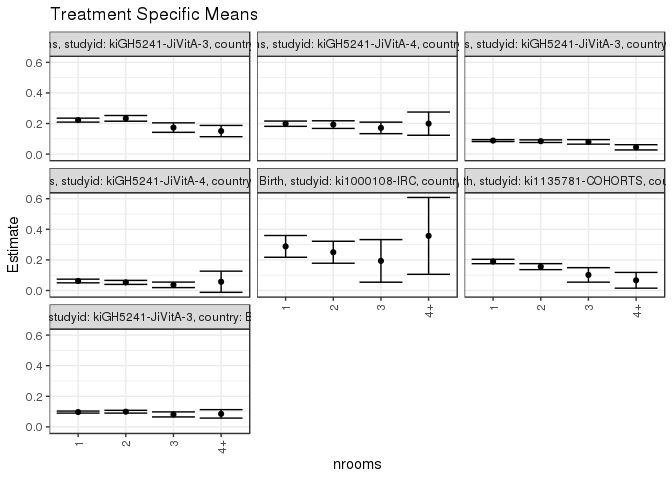

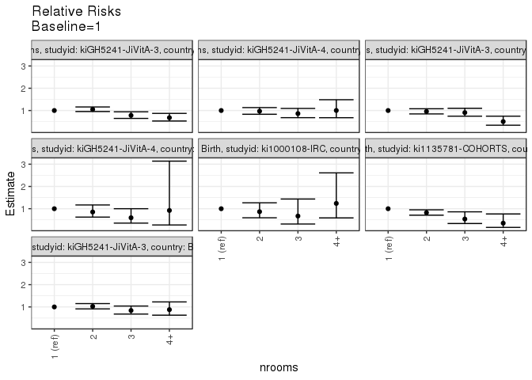

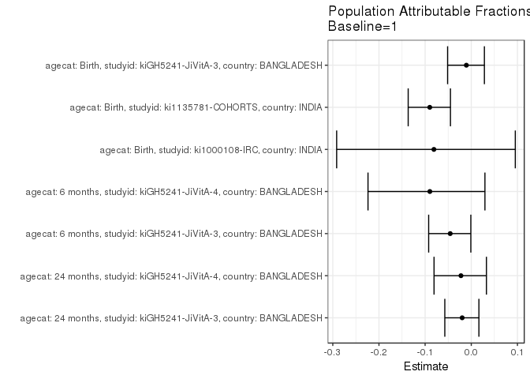

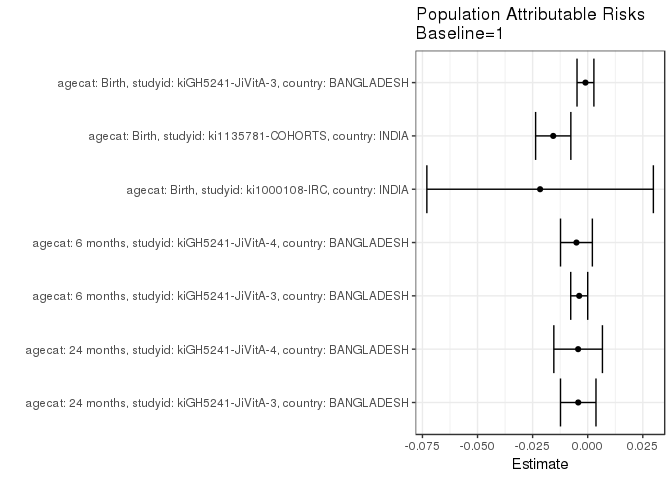

## Results Table

### Parameter: TSM

| agecat | studyid | country | intervention_level | baseline_level | estimate | ci_lower | ci_upper |
| --- | --- | --- | --- | --- | --- | --- | --- |
| Birth | ki1000108-IRC | INDIA | 1 | NA | 0.2884615 | 0.2172637 | 0.3596594 |
| Birth | ki1000108-IRC | INDIA | 2 | NA | 0.2500000 | 0.1781673 | 0.3218327 |
| Birth | ki1000108-IRC | INDIA | 3 | NA | 0.1935484 | 0.0542683 | 0.3328284 |
| Birth | ki1000108-IRC | INDIA | 4+ | NA | 0.3571429 | 0.1057806 | 0.6085051 |
| Birth | ki1135781-COHORTS | INDIA | 1 | NA | 0.1896492 | 0.1753277 | 0.2039707 |
| Birth | ki1135781-COHORTS | INDIA | 2 | NA | 0.1558735 | 0.1363621 | 0.1753849 |
| Birth | ki1135781-COHORTS | INDIA | 3 | NA | 0.1019108 | 0.0545830 | 0.1492387 |
| Birth | ki1135781-COHORTS | INDIA | 4+ | NA | 0.0666667 | 0.0151262 | 0.1182071 |
| Birth | kiGH5241-JiVitA-3 | BANGLADESH | 1 | NA | 0.0969666 | 0.0902007 | 0.1037326 |
| Birth | kiGH5241-JiVitA-3 | BANGLADESH | 2 | NA | 0.0993295 | 0.0901218 | 0.1085372 |
| Birth | kiGH5241-JiVitA-3 | BANGLADESH | 3 | NA | 0.0814873 | 0.0650664 | 0.0979083 |
| Birth | kiGH5241-JiVitA-3 | BANGLADESH | 4+ | NA | 0.0851485 | 0.0573664 | 0.1129307 |
| 6 months | kiGH5241-JiVitA-3 | BANGLADESH | 1 | NA | 0.0883363 | 0.0821418 | 0.0945308 |
| 6 months | kiGH5241-JiVitA-3 | BANGLADESH | 2 | NA | 0.0845309 | 0.0758829 | 0.0931788 |
| 6 months | kiGH5241-JiVitA-3 | BANGLADESH | 3 | NA | 0.0799763 | 0.0651557 | 0.0947969 |
| 6 months | kiGH5241-JiVitA-3 | BANGLADESH | 4+ | NA | 0.0444744 | 0.0273180 | 0.0616308 |
| 6 months | kiGH5241-JiVitA-4 | BANGLADESH | 1 | NA | 0.0620835 | 0.0501886 | 0.0739783 |
| 6 months | kiGH5241-JiVitA-4 | BANGLADESH | 2 | NA | 0.0530179 | 0.0399295 | 0.0661064 |
| 6 months | kiGH5241-JiVitA-4 | BANGLADESH | 3 | NA | 0.0368853 | 0.0189604 | 0.0548101 |
| 6 months | kiGH5241-JiVitA-4 | BANGLADESH | 4+ | NA | 0.0572519 | -0.0119893 | 0.1264931 |
| 24 months | kiGH5241-JiVitA-3 | BANGLADESH | 1 | NA | 0.2222002 | 0.2092614 | 0.2351389 |
| 24 months | kiGH5241-JiVitA-3 | BANGLADESH | 2 | NA | 0.2339181 | 0.2152262 | 0.2526101 |
| 24 months | kiGH5241-JiVitA-3 | BANGLADESH | 3 | NA | 0.1733668 | 0.1423273 | 0.2044063 |
| 24 months | kiGH5241-JiVitA-3 | BANGLADESH | 4+ | NA | 0.1506849 | 0.1138442 | 0.1875257 |
| 24 months | kiGH5241-JiVitA-4 | BANGLADESH | 1 | NA | 0.1988493 | 0.1815956 | 0.2161031 |
| 24 months | kiGH5241-JiVitA-4 | BANGLADESH | 2 | NA | 0.1928808 | 0.1679035 | 0.2178581 |
| 24 months | kiGH5241-JiVitA-4 | BANGLADESH | 3 | NA | 0.1714286 | 0.1337363 | 0.2091209 |
| 24 months | kiGH5241-JiVitA-4 | BANGLADESH | 4+ | NA | 0.1992032 | 0.1231897 | 0.2752167 |

### Parameter: E(Y)

| agecat | studyid | country | intervention_level | baseline_level | estimate | ci_lower | ci_upper |
| --- | --- | --- | --- | --- | --- | --- | --- |
| Birth | ki1000108-IRC | INDIA | NA | NA | 0.2668622 | 0.2198462 | 0.3138781 |
| Birth | ki1135781-COHORTS | INDIA | NA | NA | 0.1740009 | 0.1628660 | 0.1851358 |
| Birth | kiGH5241-JiVitA-3 | BANGLADESH | NA | NA | 0.0959454 | 0.0907405 | 0.1011503 |
| 6 months | kiGH5241-JiVitA-3 | BANGLADESH | NA | NA | 0.0844810 | 0.0796719 | 0.0892901 |
| 6 months | kiGH5241-JiVitA-4 | BANGLADESH | NA | NA | 0.0569712 | 0.0481278 | 0.0658146 |
| 24 months | kiGH5241-JiVitA-3 | BANGLADESH | NA | NA | 0.2179025 | 0.2080266 | 0.2277783 |
| 24 months | kiGH5241-JiVitA-4 | BANGLADESH | NA | NA | 0.1945032 | 0.1812962 | 0.2077102 |

### Parameter: RR

| agecat | studyid | country | intervention_level | baseline_level | estimate | ci_lower | ci_upper |
| --- | --- | --- | --- | --- | --- | --- | --- |
| Birth | ki1000108-IRC | INDIA | 1 | 1 | 1.0000000 | 1.0000000 | 1.0000000 |
| Birth | ki1000108-IRC | INDIA | 2 | 1 | 0.8666667 | 0.5933999 | 1.2657756 |
| Birth | ki1000108-IRC | INDIA | 3 | 1 | 0.6709677 | 0.3135491 | 1.4358123 |
| Birth | ki1000108-IRC | INDIA | 4+ | 1 | 1.2380952 | 0.5872740 | 2.6101612 |
| Birth | ki1135781-COHORTS | INDIA | 1 | 1 | 1.0000000 | 1.0000000 | 1.0000000 |
| Birth | ki1135781-COHORTS | INDIA | 2 | 1 | 0.8219044 | 0.7101207 | 0.9512844 |
| Birth | ki1135781-COHORTS | INDIA | 3 | 1 | 0.5373650 | 0.3356850 | 0.8602146 |
| Birth | ki1135781-COHORTS | INDIA | 4+ | 1 | 0.3515263 | 0.1616604 | 0.7643844 |
| Birth | kiGH5241-JiVitA-3 | BANGLADESH | 1 | 1 | 1.0000000 | 1.0000000 | 1.0000000 |
| Birth | kiGH5241-JiVitA-3 | BANGLADESH | 2 | 1 | 1.0243681 | 0.9125286 | 1.1499147 |
| Birth | kiGH5241-JiVitA-3 | BANGLADESH | 3 | 1 | 0.8403648 | 0.6793218 | 1.0395853 |
| Birth | kiGH5241-JiVitA-3 | BANGLADESH | 4+ | 1 | 0.8781218 | 0.6292772 | 1.2253707 |
| 6 months | kiGH5241-JiVitA-3 | BANGLADESH | 1 | 1 | 1.0000000 | 1.0000000 | 1.0000000 |
| 6 months | kiGH5241-JiVitA-3 | BANGLADESH | 2 | 1 | 0.9569211 | 0.8478543 | 1.0800181 |
| 6 months | kiGH5241-JiVitA-3 | BANGLADESH | 3 | 1 | 0.9053619 | 0.7456251 | 1.0993195 |
| 6 months | kiGH5241-JiVitA-3 | BANGLADESH | 4+ | 1 | 0.5034669 | 0.3401671 | 0.7451600 |
| 6 months | kiGH5241-JiVitA-4 | BANGLADESH | 1 | 1 | 1.0000000 | 1.0000000 | 1.0000000 |
| 6 months | kiGH5241-JiVitA-4 | BANGLADESH | 2 | 1 | 0.8539783 | 0.6241664 | 1.1684048 |
| 6 months | kiGH5241-JiVitA-4 | BANGLADESH | 3 | 1 | 0.5941236 | 0.3529264 | 1.0001599 |
| 6 months | kiGH5241-JiVitA-4 | BANGLADESH | 4+ | 1 | 0.9221762 | 0.2711016 | 3.1368648 |
| 24 months | kiGH5241-JiVitA-3 | BANGLADESH | 1 | 1 | 1.0000000 | 1.0000000 | 1.0000000 |
| 24 months | kiGH5241-JiVitA-3 | BANGLADESH | 2 | 1 | 1.0527361 | 0.9547961 | 1.1607224 |
| 24 months | kiGH5241-JiVitA-3 | BANGLADESH | 3 | 1 | 0.7802282 | 0.6460566 | 0.9422643 |
| 24 months | kiGH5241-JiVitA-3 | BANGLADESH | 4+ | 1 | 0.6781495 | 0.5281589 | 0.8707356 |
| 24 months | kiGH5241-JiVitA-4 | BANGLADESH | 1 | 1 | 1.0000000 | 1.0000000 | 1.0000000 |
| 24 months | kiGH5241-JiVitA-4 | BANGLADESH | 2 | 1 | 0.9699846 | 0.8314665 | 1.1315792 |
| 24 months | kiGH5241-JiVitA-4 | BANGLADESH | 3 | 1 | 0.8621028 | 0.6794237 | 1.0938995 |
| 24 months | kiGH5241-JiVitA-4 | BANGLADESH | 4+ | 1 | 1.0017795 | 0.6762250 | 1.4840656 |

### Parameter: PAR

| agecat | studyid | country | intervention_level | baseline_level | estimate | ci_lower | ci_upper |
| --- | --- | --- | --- | --- | --- | --- | --- |
| Birth | ki1000108-IRC | INDIA | 1 | NA | -0.0215994 | -0.0729958 | 0.0297971 |
| Birth | ki1135781-COHORTS | INDIA | 1 | NA | -0.0156483 | -0.0236444 | -0.0076522 |
| Birth | kiGH5241-JiVitA-3 | BANGLADESH | 1 | NA | -0.0010212 | -0.0048487 | 0.0028063 |
| 6 months | kiGH5241-JiVitA-3 | BANGLADESH | 1 | NA | -0.0038553 | -0.0077092 | -0.0000013 |
| 6 months | kiGH5241-JiVitA-4 | BANGLADESH | 1 | NA | -0.0051123 | -0.0123367 | 0.0021122 |
| 24 months | kiGH5241-JiVitA-3 | BANGLADESH | 1 | NA | -0.0042977 | -0.0123486 | 0.0037532 |
| 24 months | kiGH5241-JiVitA-4 | BANGLADESH | 1 | NA | -0.0043462 | -0.0153749 | 0.0066826 |

### Parameter: PAF

| agecat | studyid | country | intervention_level | baseline_level | estimate | ci_lower | ci_upper |
| --- | --- | --- | --- | --- | --- | --- | --- |
| Birth | ki1000108-IRC | INDIA | 1 | NA | -0.0809383 | -0.2916232 | 0.0953805 |
| Birth | ki1135781-COHORTS | INDIA | 1 | NA | -0.0899322 | -0.1366655 | -0.0451203 |
| Birth | kiGH5241-JiVitA-3 | BANGLADESH | 1 | NA | -0.0106436 | -0.0512775 | 0.0284197 |
| 6 months | kiGH5241-JiVitA-3 | BANGLADESH | 1 | NA | -0.0456348 | -0.0923126 | -0.0009516 |
| 6 months | kiGH5241-JiVitA-4 | BANGLADESH | 1 | NA | -0.0897344 | -0.2237162 | 0.0295782 |
| 24 months | kiGH5241-JiVitA-3 | BANGLADESH | 1 | NA | -0.0197231 | -0.0573296 | 0.0165459 |
| 24 months | kiGH5241-JiVitA-4 | BANGLADESH | 1 | NA | -0.0223449 | -0.0806613 | 0.0328244 |